# Vignette: Weighted BACON algorithms

## Robust linear regression

The education data is on education expenditures in 50 US states in 1975 (Chatterjee and Hadi, 2012, Chap. 5.7). The data can be loaded from the `robustbase` package.

```r
> data(education, package = "robustbase")
```

It is convenient to rename the variables.

```r
> names(education)[3:6] <- c("RES", "INC", "YOUNG", "EXP")
> head(education)
  State Region RES  INC YOUNG EXP
1    ME      1 508 3944   325 235
2    NH      1 564 4578   323 231
3    VT      1 322 4011   328 270
4    MA      1 846 5233   305 261
5    RI      1 871 4780   303 300
6    CT      1 774 5889   307 317
```

The measured variables for the 50 states are:

- `State`: State
- `Region`: group variable with outcomes: 1=Northeastern, 2=North central, 3=Southern, and 4=Western
- `RES`: Number of residents per thousand residing in urban areas in 1970
- `INC`: Per capita personal income in 1973 ($US)
- `YOUNG`: Number of residents per thousand under 18 years of age in 1974
- `EXP`: Per capita expenditure on public education in a state ($US), projected for 1975

### Model fit

We want to regress education expenditures (`EXP`) on the variables `RES`, `INC`, and `YOUNG` by the BACON algorithm, and obtain

```r
> reg <- wBACON_reg(EXP ~ RES + INC + YOUNG, data = education)
> reg

Call:
wBACON_reg(formula = EXP ~ RES + INC + YOUNG, data = education)

Regression on the subset of 49 out of 50 observations (98%)

Coefficients:
(Intercept)          RES          INC        YOUNG
 -277.57731      0.06679      0.04829      0.88693
```

The instance `reg` is an object of the class `wbaconlm`. The printed output of `wBACON_reg` is identical with the one of the `lm` function. In addition, we are told the size of the subset on which the regression has been computed. The observations not in the subset are considered outliers (here 1 out of 50 observations).

The `summary()` method can be used to obtain a summary of the estimated model.

```r
> summary(reg)

Call:
wBACON_reg(formula = EXP ~ RES + INC + YOUNG, data = education)

Residuals:
    Min      1Q  Median      3Q     Max
-81.128 -22.154  -7.542  22.542  80.890

Coefficients:
              Estimate Std. Error t value Pr(>|t|)
(Intercept) -277.57731  132.42286  -2.096 0.041724 *
RES            0.06679    0.04934   1.354 0.182591
INC            0.04829    0.01215   3.976 0.000252 ***
YOUNG          0.88693    0.33114   2.678 0.010291 *
---
Signif. codes:  0 '***' 0.001 '**' 0.01 '*' 0.05 '.' 0.1 ' ' 1

Residual standard error: 35.81 on 45 degrees of freedom
Multiple R-squared:  0.4967,    Adjusted R-squared:  0.4631
F-statistic:  14.8 on 3 and 45 DF,  p-value: 7.653e-07
```

The summary output of `wBACON_reg` is identical with the output of the `lm` estimate on the subset of outlier-free data,

```r
> summary(lm(EXP ~ RES + INC + YOUNG, data = education[!is_outlier(reg), ]))

Call:
lm(formula = EXP ~ RES + INC + YOUNG, data = education[!is_outlier(reg),
    ])

Residuals:
    Min      1Q  Median      3Q     Max
-81.128 -22.154  -7.542  22.542  80.890

Coefficients:
              Estimate Std. Error t value Pr(>|t|)
(Intercept) -277.57731  132.42286  -2.096 0.041724 *
RES            0.06679    0.04934   1.354 0.182591
INC            0.04829    0.01215   3.976 0.000252 ***
YOUNG          0.88693    0.33114   2.678 0.010291 *
---
Signif. codes:  0 '***' 0.001 '**' 0.01 '*' 0.05 '.' 0.1 ' ' 1

Residual standard error: 35.81 on 45 degrees of freedom
Multiple R-squared:  0.4967,    Adjusted R-squared:  0.4631
F-statistic:  14.8 on 3 and 45 DF,  p-value: 7.653e-07
```

### Tuning

By default, `wBACON_reg` uses the parametrization $\alpha = 0.05$, `collect = 4`, and `version = "V2"`. These parameters are used to call the `wBACON` algorithm on the design matrix. Then, the same parameters are used to compute the robust regression.

The parameter `collect` specifies the initial subset size, which is defined as $m = p \cdot collect$. It can be modified but should be chosen such that $m$ is considerably smaller than the number of observations $n$. Otherwise there is a high risk of selecting too many “bad” observations into the initial subset, which will eventually bias the regression estimates.

In case the algorithm does not converge, we may increase the maximum number of iterations (default: `maxiter = 50`) and toggle `verbose = TRUE` to (hopefully) learn more why the method did not converge.

### Model diagnostics

The methods `coef()`, `vcov()`, and `predict()` work exactly the same as their `lm` counterparts. This is also true for the first three `plot` types, that is

- `which = 1`: Residuals vs Fitted,
- `which = 2`: Normal Q-Q,
- `which = 3`: Scale-Location

The plot types `4:6` of `plot.lm` are not implemented for objects of the class `wbaconlm` because it is not sensible to study the standard regression influence diagnostics in the presence of outliers in the model’s design space. Instead, type four (`which = 4`) plots the robust Mahalanobis distances with respect to the non-constant design variables against the standardized residual. This plot has been proposed by Rousseeuw and van Zomeren (1990).

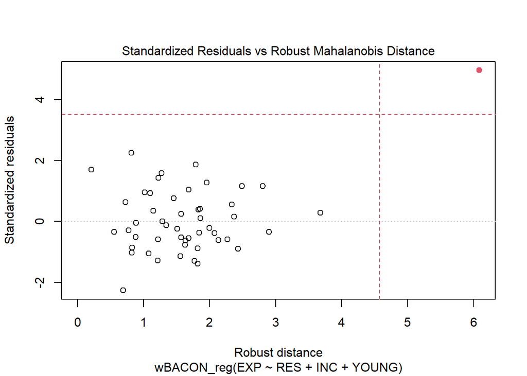

```r
> plot(reg, 4)
```

The *filled* circle(s) represent the outliers nominated by the BACON algorithm. The outlier in the top right corner is both a residual outlier and an outlier in the model’s design space.

- Observation with robust Mahalanobis distances larger than 4.57 (see abscissae) are flagged as outliers in the model’s design space (leverage observations).
- Observations whose standardized residual falls outside the interval spanned by $\pm \, t_{\alpha/(2m+2), m - p}$, where $t_{\alpha, m - p}$ is the $(1-\alpha)$ quantile of the Student $t$-distribution with $m-p$ degrees of freedom, $m$ denoting the size of the final subset of outlier-free data. Here, we have $m=49$, $\alpha = 0.05$ (see argument `alpha` of `wBACON_reg`), thus the interval is $[-3.52, \; 3.52]$.

## References

Béguin, C. and B. Hulliger (2002). *Robust Multivariate Outlier Detection and Imputation with Incomplete Survey Data*, Deliverable D4/5.2.1/2 Part C: EUREDIT project, https://www.cs.york.ac.uk/euredit/euredit-main.html, research project funded by the European Commission, IST-1999-10226.

Béguin, C. and B. Hulliger (2008). The BACON-EEM Algorithm for Multivariate Outlier Detection in Incomplete Survey Data, *Survey Methodology*, Vol. 34, No. 1, 91–103.

Billor, N., A. S. Hadi, and P. F. Vellemann (2000). BACON: Blocked Adaptive Computationally-efficient Outlier Nominators, *Computational Statistics and Data Analysis*, 34, 279–298.

Campbell, N. A. (1989). *Bushfire Mapping using NOAA AVHRR Data*. Technical Report. Commonwealth Scientific and Industrial Research Organisation, North Ryde.

Carr, D., N. Lewin-Koh, and M. Maechler (2021). *hexbin: Hexagonal Binning Routines*. R package version 1.28.2. (The package contains copies of lattice functions written by Deepayan Sarkar).

Chatterjee, S. and A. H. Hadi (2012). *Regression Analysis by Example*, 5th ed., Hoboken (NJ): John Wiley & Sons.

Hulliger, B. and T. Schoch (2009). Robust multivariate imputation with survey data, in *Proceedings of the 57th Session of the International Statistical Institute*, Durban.

Hulliger, B. and M. Sterchi (2020). *modi: Multivariate Outlier Detection and Imputation for Incomplete Survey Data*, R package version 0.1-0.

Maechler, M., P. Rousseeuw, C. Croux, V. Todorov, A. Ruckstuhl, M. Salibian-Barrera, T. Verbeke, M. Koller, E. L. T. Conceicao, and M. Anna di Palma (2020). *robustbase: Basic Robust Statistics*, R package version 0.93-6.

Maronna, R. A. and V. J. Yohai (1995). The Behavior of the Stahel-Donoho Robust Multivariate Estimator, *Journal of the American Statistical Association*, 90, 330–341.

Qiu, W. and H. Joe (2006). Separation index and partial membership for clustering, *Computational Statistics and Data Analysis* 50, pp. 585-603.

Raymaekers, J. and P. Rousseeuw (2020). *cellWise: Analyzing Data with Cellwise Outliers*, R package version 2.2.1.

Rousseeuw, P. J. and K. van Driessen (1999). A fast algorithm for the Minimum Covariance Determinant estimator, *Technometrics*, 41, 212–223.

Rousseeuw, P. J. and K. van Zomeren (1990). Unmasking Multivariate Outliers and Leverage Points, *Journal of the American Statistical Association*, 411, 633–639.

Willems, G., H. Joe, and R. Zamar (2009). Diagnosing Multivariate Outliers Detected by Robust Estimators, *Journal of Computational and Graphical Statistics* 18, pp. 73-91.

## Notes

<sup>1</sup> The `devtools` package can be installed from CRAN by `install.packages("devtools")`.

<sup>2</sup> The data are also distributed with the `R` package `robustbase` (Maechler et al., 2020).

<sup>3</sup> The degrees of freedom $d$ is a function of the number of variables $p$, the number of observations $n$, and the size of the current subset $m$; see `methods.pdf` in the `inst/doc` folder of the package.